# ChromVAR: scATAC-seq analysis

```r
### install
install.packages(c("BiocManager", "devtools"))
BiocManager::install("GreenleafLab/chromVAR")
BiocManager::install("JASPAR2016")
devtools::install_github("GreenleafLab/motifmatchr")
devtools::install_github("GreenleafLab/chromVARmotifs")
```

[output not shown]

```r
# 元URL: https://greenleaflab.github.io/chromVAR/articles/Introduction.html
library(chromVAR)
library(motifmatchr)
library(Matrix)
library(SummarizedExperiment)
library(BiocParallel)
set.seed(2017)
```

```r
# Setting multiprocessing options
# progressbar = TRUE  でプログレスバーが表示される
register(MulticoreParam(12, progressbar = TRUE))
```

## Reading in inputs

- chromVARは、オープンクロマチンのピークリストに含まれるリードカウントの行列(カウントテーブル)を入力として受け取ります。
- カウントテーブルを作成できるソフトウェアパッケージは数多くありますが、chromVARもscATAC-seq用のメソッドを提供しています。
- カウントテーブルのオプションや他のソフトウェアで生成されたカウントテーブルの再フォーマット方法の詳細については、[Counts section of the documentation website](https://greenleaflab.github.io/chromVAR/articles/Articles/Counts.html) を参照してください。
- ピークは長さが固定長で(250bp~500bp推奨)、オーバーラップがないものが推奨される。ピーク幅による結果の違いについては [元論文のSupplement](https://drive.google.com/file/d/0B8eUn6ZURmqvUjBCbE5Hc0p4UFU/view?usp=sharing) を参照のこと。
- scATAC-seqを解析する際には同じ（または類似の）細胞群から得られた bulk ATAC or DNAse-seq data を元にしたピークリストを用いることが理にかなっている。
  - 複数のピークファイルを用いる場合は１ファイルにマージするべき。以下に示すfilterPeaks functionを用いるとオーバーラップしないピークリストを作成する（サンプル間で最も強いピークに合わせる）。
- getPeaks コマンドはピークを GenomicRangesオブジェクトとして読み込む。sort_peaks 引数はピークをソートするか否かを示す。

```r
peakfile <- system.file("extdata/test_bed.txt", package = "chromVAR") # デモデータ
peaks <- getPeaks(peakfile, sort_peaks = TRUE)
```

```
Peaks sorted
```

- narrowpeak 形式のピークを読み込むために、chromVARにはreadNarrowpeaksという関数があります。
  - これはファイルを読み込み、width引数に基づいてピークのサイズを変更し、より強いシグナルを持つピークと重なるピークを削除します (non_overlapping=TRUE (default) の場合).

## リードカウント

- 関数 getCounts は、細胞 x ピークの行列データを持つchromVARCounts オブジェクトを返します。 counts(fragment_counts) で参照できます。
- Matrix パッケージを使用しているので、行列が疎な場合は sparse Matrix として保存されます。
- その他詳細は [Counts section of the documentation website](https://greenleaflab.github.io/chromVAR/articles/Articles/Counts.html) を参照。

```r
bamfile <- system.file("extdata/test_RG.bam", package = "chromVAR")

# bamファイルは複数渡すことができ、その場合colData は、bamファイルの数だけcelltypeを指定する。
# e.g DataFrame(celltype = c("GM","K562"))
# 複数サンプルをマージするためにRGタグを使わない場合は、by_rg = FALSEとする。

fragment_counts <- getCounts(bamfile,
                             peaks,
                             paired = TRUE,
                             by_rg = TRUE,
                             format = "bam",
                             colData = DataFrame(celltype = "GM"))

data(example_counts, package = "chromVAR")
head(example_counts)
```

```
Reading in file: /usr/local/lib/R/site-library/chromVAR/extdata/test_RG.bam
```

```
class: RangedSummarizedExperiment
dim: 6 50
metadata(0):
assays(1): counts
rownames: NULL
rowData names(3): score qval name
colnames(50): singles-GM12878-140905-1 singles-GM12878-140905-2 ...
  singles-H1ESC-140820-24 singles-H1ESC-140820-25
colData names(2): Cell_Type depth
```

## Example

```r
data(example_counts, package = "chromVAR")
head(example_counts)
```

```
class: RangedSummarizedExperiment
dim: 6 50
metadata(0):
assays(1): counts
rownames: NULL
rowData names(3): score qval name
colnames(50): singles-GM12878-140905-1 singles-GM12878-140905-2 ...
  singles-H1ESC-140820-24 singles-H1ESC-140820-25
colData names(2): Cell_Type depth
```

## Getting GC content of peaks

- GC含量はバックグラウンドのピークを決定するために使用されます。
- 関数 addGCBias は、SummarizedExperimentオブジェクトに"bias "という新しい rowData 列を追加します。
  - この関数はゲノム配列の入力（BSgenome、FaFile、またはDNAStringSetオブジェクト）を必要とします。

```r
library(BSgenome.Hsapiens.UCSC.hg19)
example_counts <- addGCBias(example_counts, genome = BSgenome.Hsapiens.UCSC.hg19)
head(rowData(example_counts))
```

```
DataFrame with 6 rows and 4 columns
      score      qval        name      bias
  <integer> <numeric> <character> <numeric>
1       259  25.99629   GM_peak_6     0.652
2        82   8.21494   H1_peak_7     0.680
3       156  15.65456  GM_peak_17     0.788
4        82   8.21494  H1_peak_13     0.674
5       140  14.03065  GM_peak_27     0.600
6       189  18.99529 GM_peak_29a     0.742
```

## Filtering inputs

- 不十分なリードやピーク内のリードの割合が低いサンプルは空のウェルや死細胞を表している可能性があるため、フィルタリングして除外する。
- フィルタリングには min_in_peaksとmin_depthの2つのパラメータが使用されます。
- min_in_peaksはピーク中のフラグメントの割合の中央値の0.5倍に設定され、min_depthは最大500またはライブラリサイズの中央値の10％に設定されます。

```r
# plot = FALSEを指定すると図が生成されない
#find indices of samples to keep
counts_filtered <- filterSamples(example_counts, min_depth = 1500,
                                 min_in_peaks = 0.15, shiny = FALSE)
```

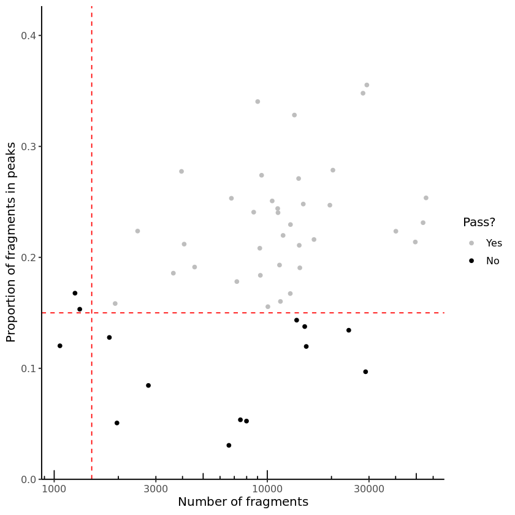

```r
#find indices of samples to keep
filtering_plot <- filterSamplesPlot(example_counts, min_depth = 1500,
                                    min_in_peaks = 0.15, use_plotly = FALSE)
filtering_plot
```

```r
# To instead return the indexes of the samples to keep instead of a new SummarizedExperiment object,
# use ix_return = TRUE.
ix <- filterSamples(example_counts, ix_return = TRUE, shiny = FALSE)
```

```
min_in_peaks set to 0.105

min_depth set to 1120.65
```

- バルクデータとシングルセルデータの両方において、ピークは少なくともリード数の最低値を定めてフィルタリングする必要があります。
- 最低でも、各ピークはすべてのサンプルにわたって少なくとも1つのフラグメントを持つ必要があります。そうでなければ、この後の関数は動作しません。
- また、関数 filterPeaks は、non_overlapping 引数が TRUE に設定されている場合（これがデフォルトです）、ピークセットをnon-overlapping ピークに縮小します（重複するピークについては、より高いカウントのピークを保持します）。

```r
counts_filtered <- filterPeaks(counts_filtered, non_overlapping = TRUE)
```

## Get motifs and what peaks contain motifs

- The function getJasparMotifs fetches motifs from the JASPAR database.

```r
motifs <- getJasparMotifs()
# デフォルトではhumanのモチーフが呼び出される。違う生物種を呼び出す時はspecies引数を指定
yeast_motifs <- getJasparMotifs(species = "Saccharomyces cerevisiae")
```

- core以外のコレクションを使用する場合は、collection引数を使用します。
  - オプション: core, cne, phylofacts, splice, polii, fam, pbm, pbm_homeo, pbm_hlh などがあります。
- getJasparMotifs関数は、TFBSToolsのgetMatrixSetの単なるラッパーです。
- motifmatchrパッケージの関数 matchMotifsは、どのピークにどのモチーフが含まれているかを検出します。デフォルトでは、SummarizedExperimentオブジェクトを返します。この関数はゲノム配列の入力を必要とします。

```r
library(motifmatchr)
motif_ix <- matchMotifs(motifs, counts_filtered,
                        genome = BSgenome.Hsapiens.UCSC.hg19)
```

- モチーフの呼び出しをどの程度厳密に行うかを決定するためのオプションp.cutoffがあります。
  - デフォルト値は0.00005で、これはヒトのモチーフに対して妥当な数のモチーフマッチを与える傾向があります。
- モチーフマッチのみを返す代わりに、ピークごとのモチーフマッチ数とピークごとの最大モチーフスコアを含む行列（アッセイとして格納されています）を返すこともできます (`out = score` オプション)。
- モチーフマッチの実際の位置を返すには、`out = positions`を使用します。`out = matches`または`out = score` の出力のどちらかをcomputeDeviations関数に渡すことができます。
- 既知のモチーフを使う代わりに、特定の長さのkmersをすべて使いたい場合は、 matchKmers関数を使うことができます。入力としてのkmersの使用についての詳細は、[Annotations section of the documentation website](https://greenleaflab.github.io/chromVAR/articles/Articles/Counts.html)を参照してください。

```r
kmer_ix <- matchKmers(6, counts_filtered,
                      genome = BSgenome.Hsapiens.UCSC.hg19)
```

## Compute deviations

- 関数 computeDeviations は、2つの "アッセイ "を持つ SummarizedExperiment オブジェクトを返します。
- 最初の行列（`deviations(dev)` または `assays(dev)$deviations` でアクセス可能）は、各細胞（列）の各ピークセット（行）に対するバイアス補正されたアクセシビリティの "偏差"を与えます。
- このスコアは、そのピークセットが細胞間で平均化されたアクセシビリティにに対してどの程度アクセシブルかを表します。その際に同程度のGC含量とアクセシビリティを持つバックグラウンドピークセットで正規化されています。
- 2番目の行列（`deviationScores(dev)`または`assays(deviations)$z`）は、偏差Zスコアを与え、これは、同程度のGC含有量と平均的なアクセシビリティを持つピークセットをランダムにサンプリングした場合に、そのようなスコアがどの程度起こりそうかを考慮します。

```r
dev <- computeDeviations(object = counts_filtered, annotations = motif_ix)
```

## Background Peaks

- 関数 computeDeviations は偏差スコアを正規化するためにバックグラウンドピークのセットを使用します。この計算はデフォルトで内部的に行われ、返されません。このステップをより制御するために、ユーザは getBackgroundPeaks 関数を自分自身で実行し、結果を background_peaks パラメータの下で computeDeviations に渡すことができます。

バックグラウンドピークは、GC コンテンツのピークと平均アクセシビリティのピークに類似したピークです。

```r
bg <- getBackgroundPeaks(object = counts_filtered)
```

getBackgroundPeaksの結果はインデックスの行列であり，各列はバックグラウンドピークであるピークのインデックスを表します．

計算されたバックグラウンドピークを使用するには，単にそれらをcomputeDeviationsの呼び出しに追加します．

```r
dev <- computeDeviations(object = counts_filtered,
                         annotations = motif_ix,
                         background_peaks = bg)
```

## Variability

- 関数 computeVariability は，以下の３つを含むdata.frameを返します。
  - Variability（あるピークセットに対して全ての細胞間で計算されるzスコアの標準偏差）
  - そのVariabilityのブートストラップ信頼区間（細胞のリサンプリングによる），
  - Variabilityが帰無仮説の1よりも大きいことを示すp値

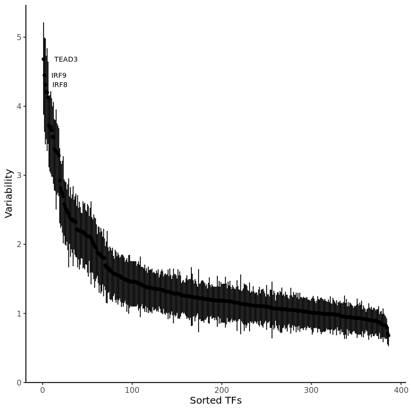

```r
variability <- computeVariability(dev)

plotVariability(variability, use_plotly = FALSE)
```

## Visualizing Deviations

- セルを可視化するためには、TSNEを使って偏差を2次元に投影すると便利です。
- そのための便利な関数がdeviationsTsneに用意されています。インタラクティブなセッションで実行している場合は、shinyをTRUEに設定することで、パラメータを探索するためのshinyなガジェットをロードすることができます。

```r
tsne_results <- deviationsTsne(dev, threshold = 1.5, perplexity = 10)
tsne_plots <- plotDeviationsTsne(dev, tsne_results,
                                 annotation_name = "TEAD3",
                                 sample_column = "Cell_Type",
                                 shiny = FALSE)
```

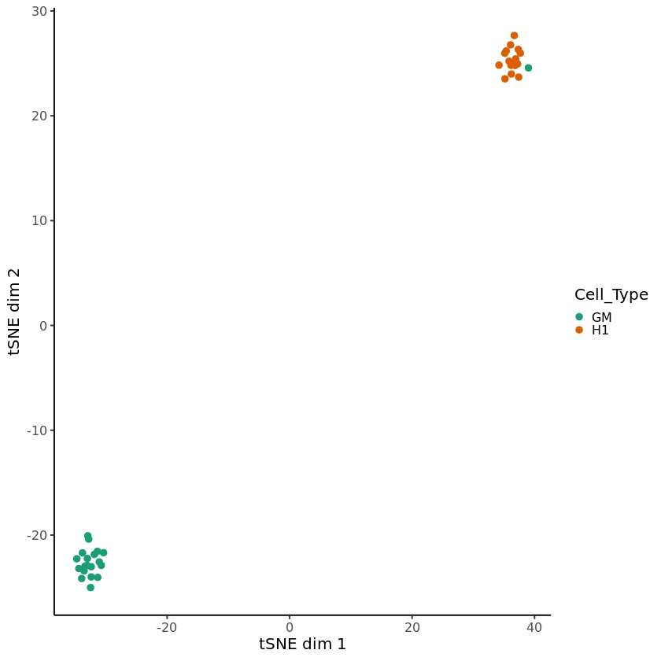

```r
tsne_plots[[1]]
```

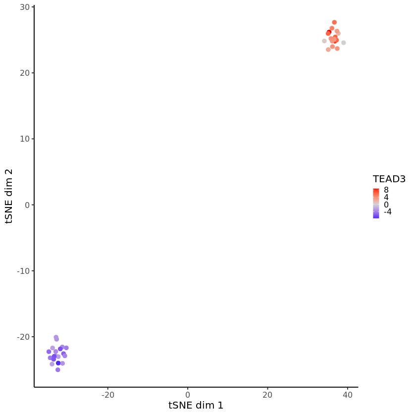

```r
tsne_plots[[2]]
```